# Bellabeat Analysis

Jaime Avendano

4/18/2021

### Background

This is a case study for the Google Data Analytics Capstone.  
Case Study 2: How can a wellness technology company play it smart?

## Executive Summary

Smart devices are becoming more common. Everyone is aware that they can track their steps, but many of these devices can track our active minutes, heart rates, sleeping behavior and more.  
The goal of this analysis is to learn how consumers are using a competitors devices. This would then be used to help the Bellabeat marketing strategy.

Primary questions:  
1. What are some trends in smart device usage?  
2. How could these trends apply to Bellabeat customers?  
3. How could these trends help influence Bellabeat’s marketing strategy?

## Dataset

The original data can be found here: https://www.kaggle.com/arashnic/fitbit

### Loading and Cleaning the data

The data focuses on daily, hourly, and minute statistics. This analysis focuses primarily on the daily and hourly tables.

**Click for Details on the Data Files**

18 CSV Files were provided.

- 4 Files with Daily data
- 3 Files with Hourly data
- 8 Files with Seconds data
- 1 File with Sleep data
- 1 File with Heart Rate data
- 1 File with Weight Loss logs
- 3 of the seconds files were redundant data, formatted in a wide format. These were ignored in favor of the long data.
- 3 of the daily files contained data already present in the main dailyActivity file. These were also ignored.

**Click for Cleaning Steps**

## Summarizing the data

**Fitbit tracker analysis (32 participants)**

Participants grouped by quantiles.

| Usage | Users | Average Days | Average Daily Steps | Average Active Minutes |
| --- | --- | --- | --- | --- |
| < 5.7k | 8 | 22.5 | 3,961 | 168 |
| 5.7-7.6k | 8 | 26.5 | 7,019 | 240 |
| 7.6-10k | 8 | 27.1 | 8,917 | 278 |
| > 10k | 8 | 29.2 | 12,460 | 294 |

Fitbit Fitness Tracker Data from Kaggle

## Plotting Usage

What are the most common step values that are reached?

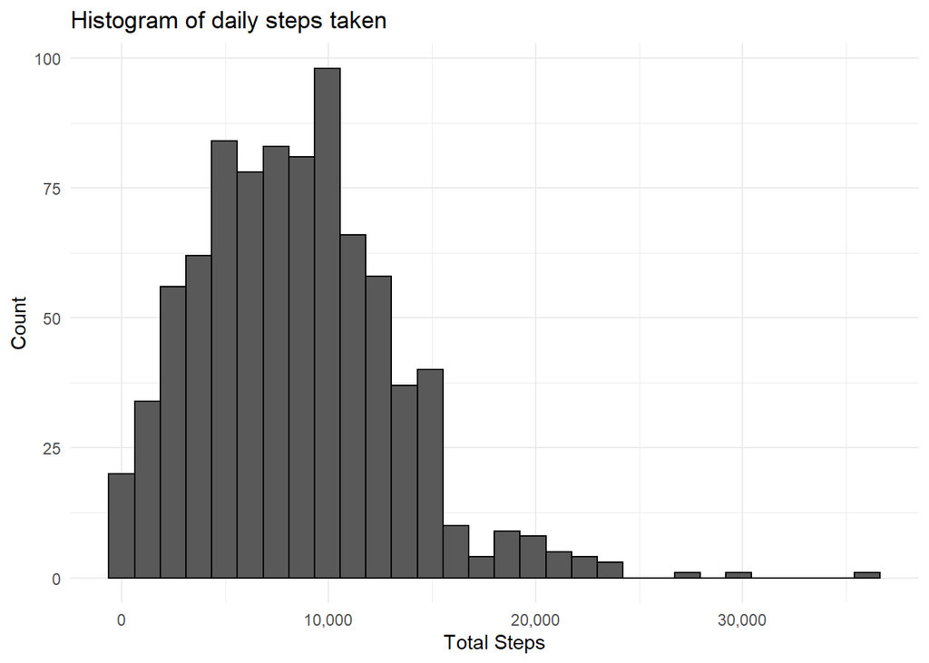

## Plotting Usage

What days do people take the most steps and what days are they the most active?

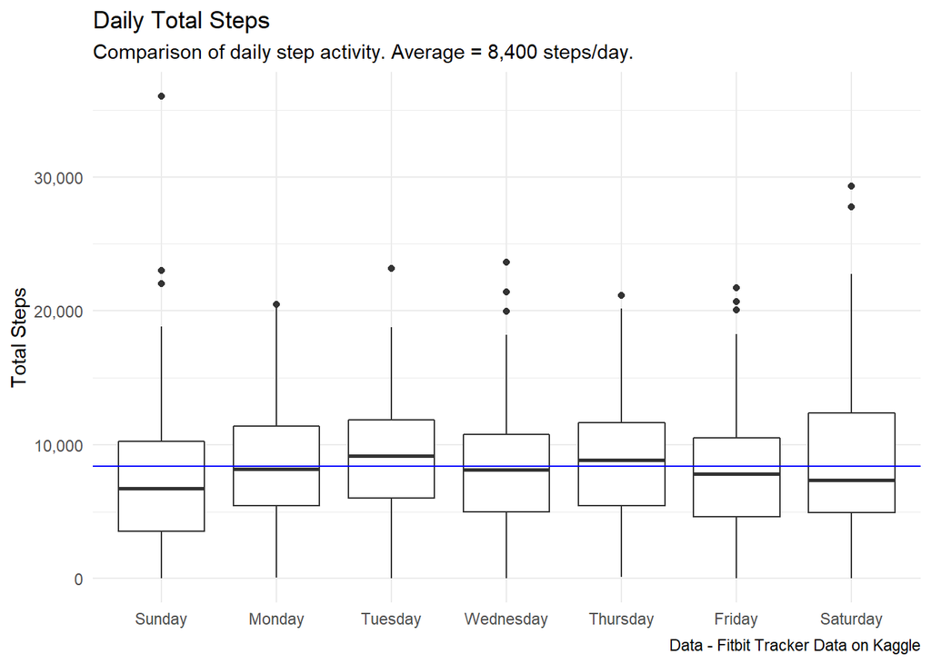

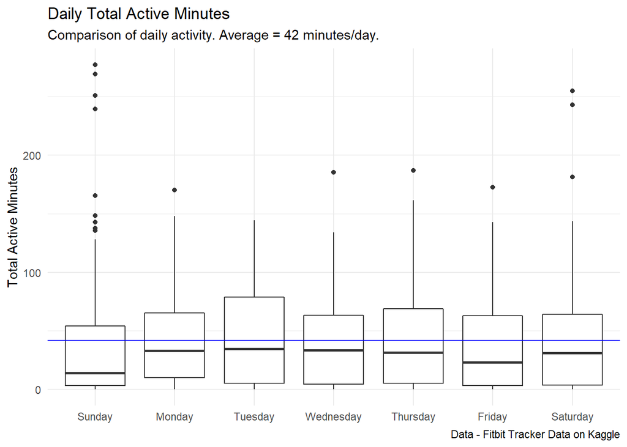

How active are people throughout the day? Most people typically have different schedules on weekends.

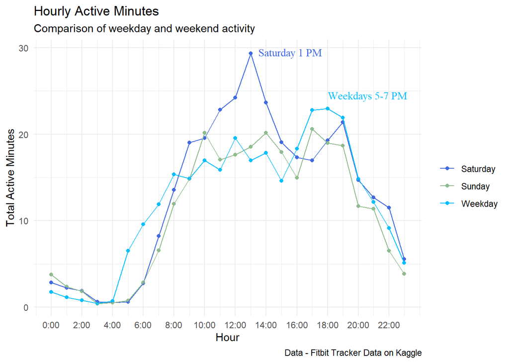

## Conclusions

Trends:

- 10k is a goal that seems to be what a lot of users aim for.
- During the week, users are slightly more active on Tuesdays and Thursdays.
- Sundays is the least active days.

There are a few interesting peaks in activity during the day:

- Saturdays at 1PM.
- Weekdays between 5-7 PM.
- Weekdays at noon.

Takeaways: Marketing could target those areas of higher activity to encourage people to do even more. For example, they could target those that exercise after school and work, as they could enjoy seeing how hard they were working.

There are also other activities that could be encouraged. For example, people seem to take short walks at lunch. Being able to see how how small activities add up could be encouraging.

Another strategy is to focus on less active days, like Sundays. We could encourage people to be more active during those times.